# Analyzing the quality of red wines (by Aishwarya Venketeswaran)

#### Firstly, I would like to explore the univariate relationships that

#### exist in this dataset.

# Univariate Plots Section

```
## [1] 1599   13
```

```
##  [1] "X"                    "fixed.acidity"        "volatile.acidity"
##  [4] "citric.acid"          "residual.sugar"       "chlorides"
##  [7] "free.sulfur.dioxide"  "total.sulfur.dioxide" "density"
## [10] "pH"                   "sulphates"            "alcohol"
## [13] "quality"
```

```
## 'data.frame':    1599 obs. of  13 variables:
##  $ X                   : int  1 2 3 4 5 6 7 8 9 10 ...
##  $ fixed.acidity       : num  7.4 7.8 7.8 11.2 7.4 7.4 7.9 7.3 7.8 7.5 ...
##  $ volatile.acidity    : num  0.7 0.88 0.76 0.28 0.7 0.66 0.6 0.65 0.58 0.5 ...
##  $ citric.acid         : num  0 0 0.04 0.56 0 0 0.06 0 0.02 0.36 ...
##  $ residual.sugar      : num  1.9 2.6 2.3 1.9 1.9 1.8 1.6 1.2 2 6.1 ...
##  $ chlorides           : num  0.076 0.098 0.092 0.075 0.076 0.075 0.069 0.065 0.073 0.071 ...
##  $ free.sulfur.dioxide : num  11 25 15 17 11 13 15 15 9 17 ...
##  $ total.sulfur.dioxide: num  34 67 54 60 34 40 59 21 18 102 ...
##  $ density             : num  0.998 0.997 0.997 0.998 0.998 ...
##  $ pH                  : num  3.51 3.2 3.26 3.16 3.51 3.51 3.3 3.39 3.36 3.35 ...
##  $ sulphates           : num  0.56 0.68 0.65 0.58 0.56 0.56 0.46 0.47 0.57 0.8 ...
##  $ alcohol             : num  9.4 9.8 9.8 9.8 9.4 9.4 9.4 10 9.5 10.5 ...
##  $ quality             : int  5 5 5 6 5 5 5 7 7 5 ...
```

```
##        X          fixed.acidity   volatile.acidity  citric.acid
##  Min.   :   1.0   Min.   : 4.60   Min.   :0.1200   Min.   :0.000
##  1st Qu.: 400.5   1st Qu.: 7.10   1st Qu.:0.3900   1st Qu.:0.090
##  Median : 800.0   Median : 7.90   Median :0.5200   Median :0.260
##  Mean   : 800.0   Mean   : 8.32   Mean   :0.5278   Mean   :0.271
##  3rd Qu.:1199.5   3rd Qu.: 9.20   3rd Qu.:0.6400   3rd Qu.:0.420
##  Max.   :1599.0   Max.   :15.90   Max.   :1.5800   Max.   :1.000
##  residual.sugar     chlorides       free.sulfur.dioxide
##  Min.   : 0.900   Min.   :0.01200   Min.   : 1.00
##  1st Qu.: 1.900   1st Qu.:0.07000   1st Qu.: 7.00
##  Median : 2.200   Median :0.07900   Median :14.00
##  Mean   : 2.539   Mean   :0.08747   Mean   :15.87
##  3rd Qu.: 2.600   3rd Qu.:0.09000   3rd Qu.:21.00
##  Max.   :15.500   Max.   :0.61100   Max.   :72.00
##  total.sulfur.dioxide    density             pH          sulphates
##  Min.   :  6.00       Min.   :0.9901   Min.   :2.740   Min.   :0.3300
##  1st Qu.: 22.00       1st Qu.:0.9956   1st Qu.:3.210   1st Qu.:0.5500
##  Median : 38.00       Median :0.9968   Median :3.310   Median :0.6200
##  Mean   : 46.47       Mean   :0.9967   Mean   :3.311   Mean   :0.6581
##  3rd Qu.: 62.00       3rd Qu.:0.9978   3rd Qu.:3.400   3rd Qu.:0.7300
##  Max.   :289.00       Max.   :1.0037   Max.   :4.010   Max.   :2.0000
##     alcohol         quality
##  Min.   : 8.40   Min.   :3.000
##  1st Qu.: 9.50   1st Qu.:5.000
##  Median :10.20   Median :6.000
##  Mean   :10.42   Mean   :5.636
##  3rd Qu.:11.10   3rd Qu.:6.000
##  Max.   :14.90   Max.   :8.000
```

#### There are several variables provided by the data set. What are the

#### relationships of these variables? What are the mean, median, mode, 25th & 75th

#### percentiles of all these variables?

## Graph of count vs. fixed.acidity

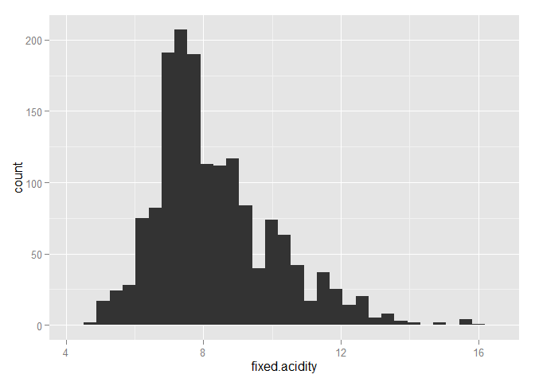

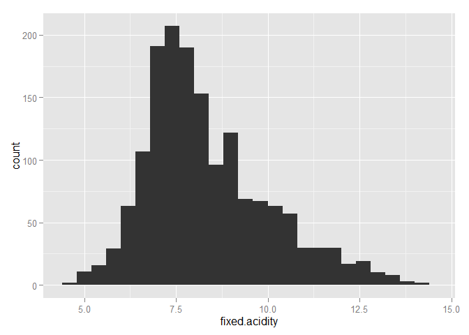

#### After transforming the graph, it can be recognized that the distribution

#### is unimodal with the peak at about 8gm/dm^3. There seems to be a gap at

#### 14-15g/dm^3 implying that there are no values in this reange. But, there are

#### some values greater than 15 g/dm^3.

## Graph of count vs. volatile.acidity

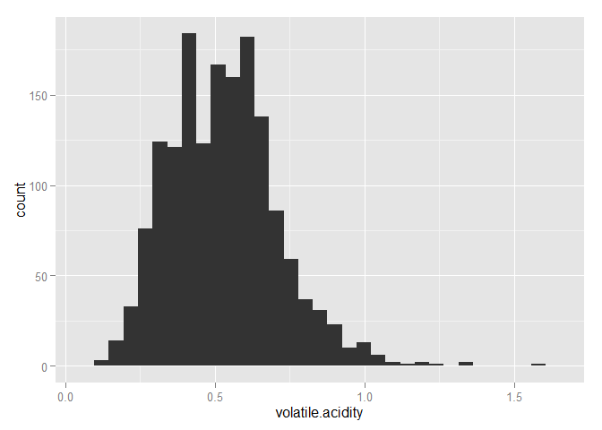

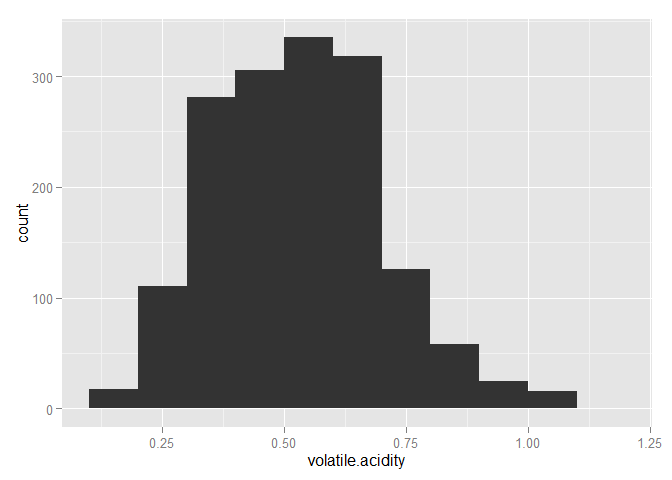

## Graph of count vs. citric.acidity

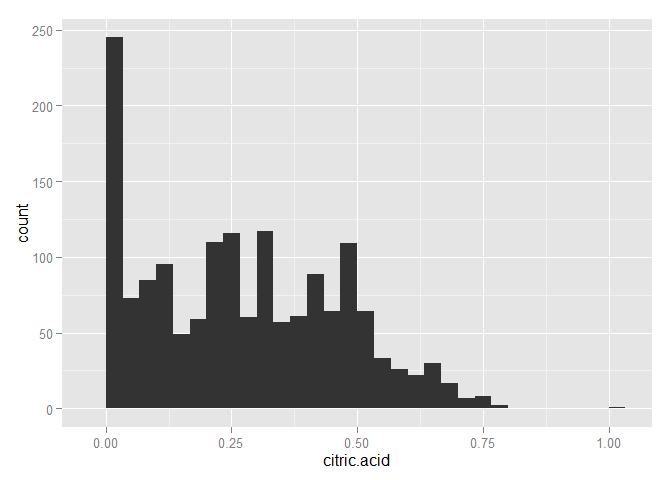

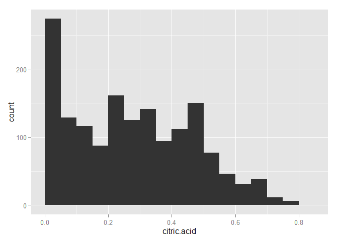

## Graph of count vs. residual.sugar

### How sweet are wines?

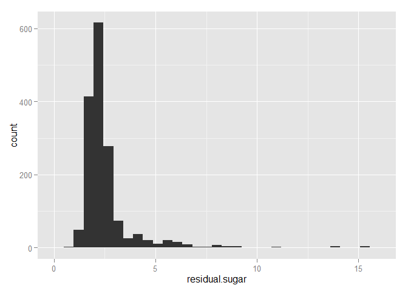

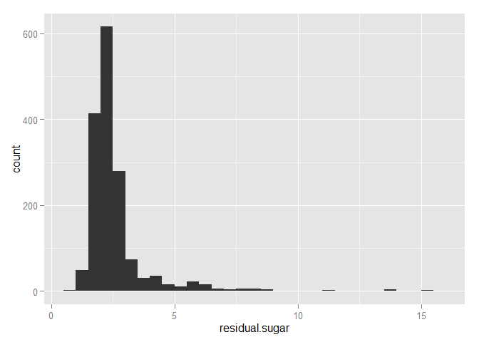

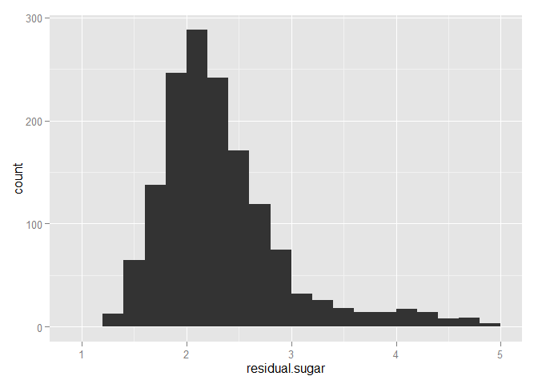

```
##    Min. 1st Qu.  Median    Mean 3rd Qu.    Max.
##   0.900   1.900   2.200   2.539   2.600  15.500
```

#### dataset, it is rare to find wines that have residual sugars less than

#### 1gm/liter.Let us look at how many wines have residual sugar values less than

#### 1 gm/liter.

```
##    Min. 1st Qu.  Median    Mean 3rd Qu.    Max.
##   0.900   1.900   2.200   2.539   2.600  15.500
```

```
## [1] 2
```

#### The minimum value for residual sugars is 0.90gm/liter (so, less than 1).

#### After examining the frequencies, it can be concluded that there are 2 wines

#### (rare wines) that have values of residual sugars less than 1. The most common

#### value for residual sugars is 2gm/liter.The data set states that wines with

#### residual sugars greater than 45gm/liter are considered to be sweet. In this

#### data set, the maximum value for residual sugar is 15.5 gm/liter. Hence, in

#### this sample, there are no wines that are sweet.

## Graph of count vs. chlorides

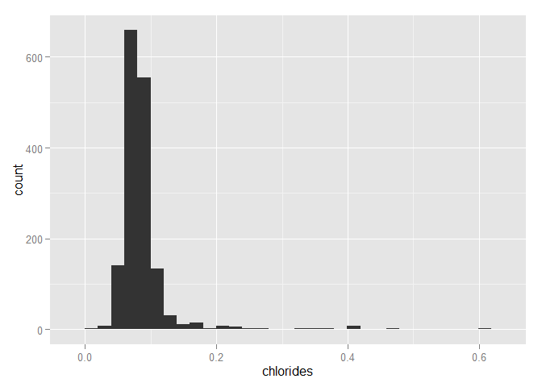

```
## [1] 67
```

```
## [1] 50
```

```
## [1] 0
```

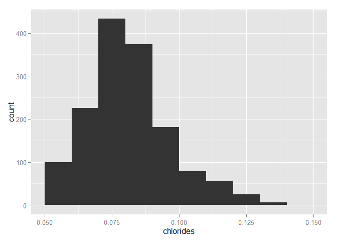

#### None of the wines have chlorides level equal to 0.

## Graph of count vs. free.sulfur.dioxide

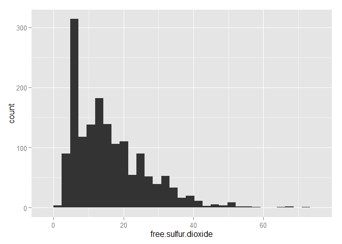

```
## [1] 16
```

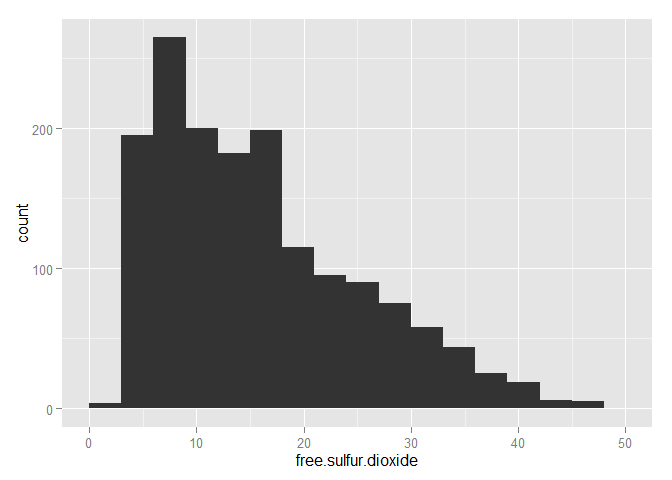

```
##    Min. 1st Qu.  Median    Mean 3rd Qu.    Max.
##    1.00    7.00   14.00   15.87   21.00   72.00
```

#### Distribution has a peak at about 10mg/dm^3.The mean is at 15.87mg/dm^3

## Graph of count vs. total.sulfur.dioxide

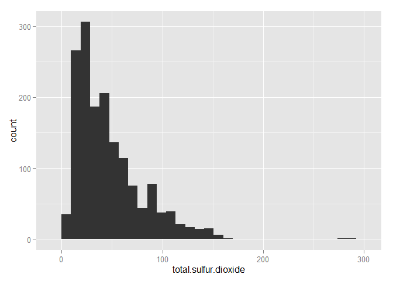

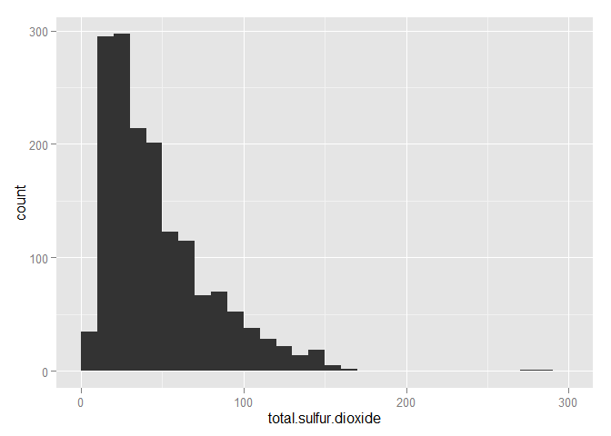

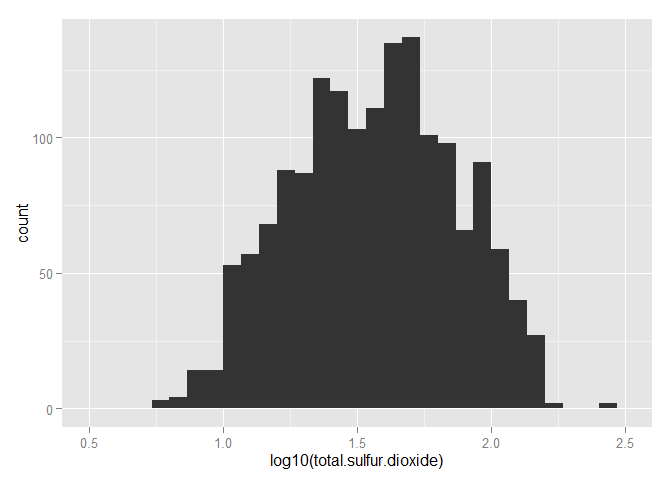

```
##    Min. 1st Qu.  Median    Mean 3rd Qu.    Max.
##    6.00   22.00   38.00   46.47   62.00  289.00
```

```
##    Mode   FALSE    TRUE    NA's
## logical    1596       3       0
```

## Graph of count vs. density

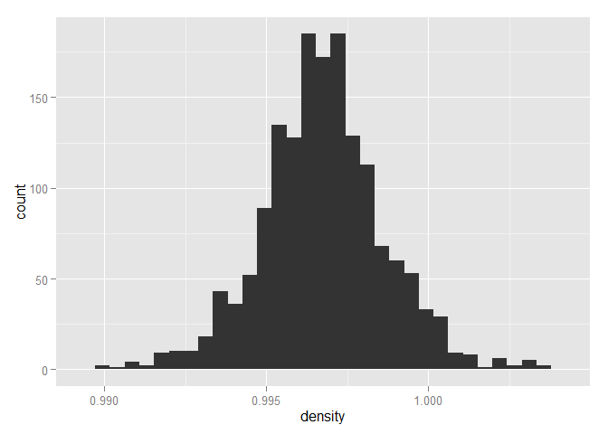

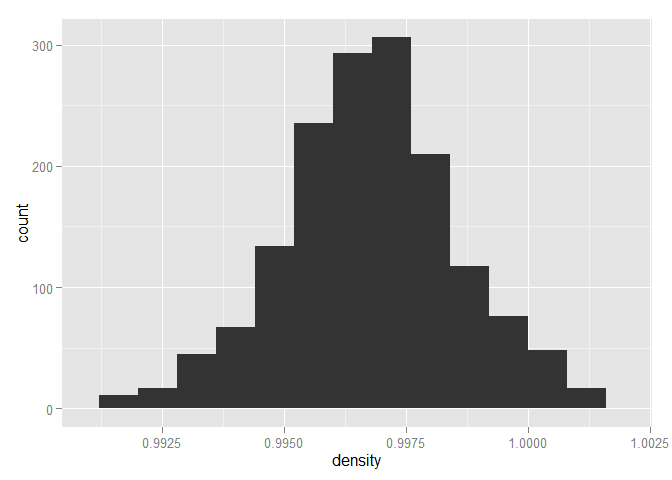

```
##    Min. 1st Qu.  Median    Mean 3rd Qu.    Max.
##  0.9901  0.9956  0.9968  0.9967  0.9978  1.0040
```

#### Distribution seems to be unimodal with the peak at about 0.9975g/cm^3.The

#### mean is at 0.9967g/cm^3.The most common density is 0.9972 g/cm^3.

## Graph of count vs. pH

### How acidic are wines? What is the most common pH value?

### What is the minimum pH value a wine has?

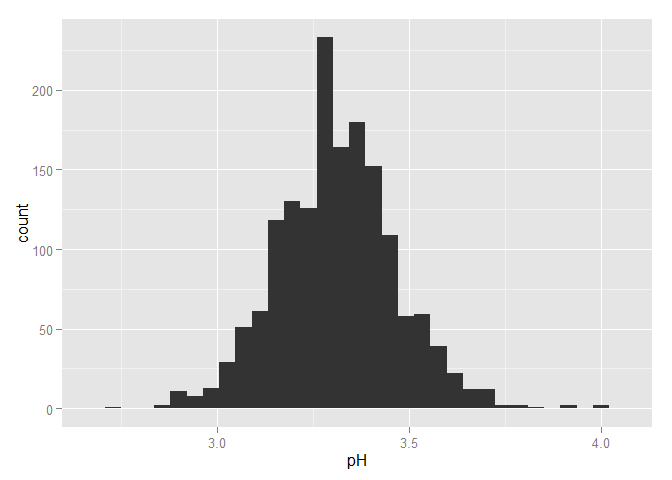

```
##    Min. 1st Qu.  Median    Mean 3rd Qu.    Max.
##   2.740   3.210   3.310   3.311   3.400   4.010
```

```
##    Mode   FALSE    NA's
## logical    1599       0
```

```
##    Mode   FALSE    TRUE    NA's
## logical    1598       1       0
```

```
##    Mode   FALSE    TRUE    NA's
## logical    1594       5       0
```

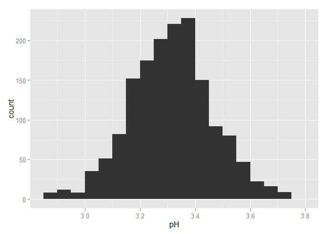

#### Distribution seems to be unimodal with the peak at about 3.4.The mean is

#### at 3.3.The most common PH is 3.3.From the graph, it can be seen that there are

#### few values before 2.8 and after 3.8. The minimum is 2.74 and the maximum is

#### 4.01. By using R commands, it can be determined that there are no wines with

#### pH values between 2.75 and 2.85 (the gap in the graph). Also, there is exactly

#### one wine whose pH value is less than 2.85. I think the given minimum (2.74) is

#### an outlier. There are only 5 wines whose pH values are greater than 3.8; hence,

#### they may be outliers.

## Graph of count vs. sulphates

## What kind of distribution does this graph have?

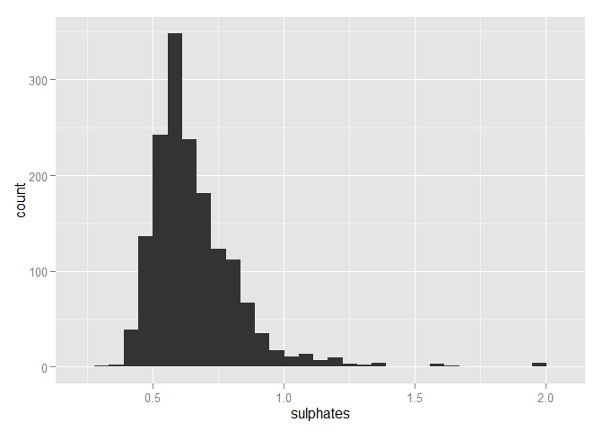

```
##    Min. 1st Qu.  Median    Mean 3rd Qu.    Max.
##  0.3300  0.5500  0.6200  0.6581  0.7300  2.0000
```

```
##    Mode   FALSE    TRUE    NA's
## logical    1571      28       0
```

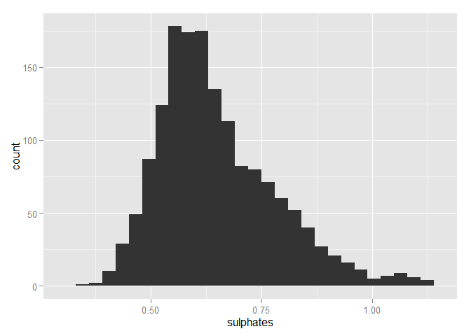

#### The distribution is unimodal with the peak at 0.6g/dm^3. The minimum value

#### is 0.33g/dm^3 and the maximum is 2g/dm^3.There are only 8 wines that have

#### sulphates more than 1.5g/dm^3. These may be outliers.

## Graph of count vs. alcohol

### How much alcohol is there in wines?

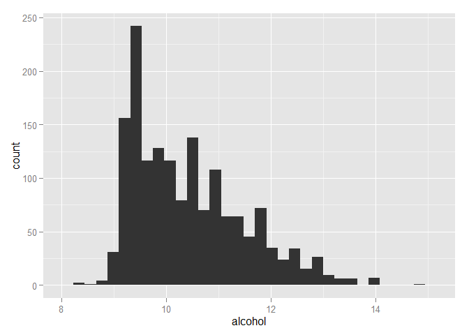

```
##    Min. 1st Qu.  Median    Mean 3rd Qu.    Max.
##    8.40    9.50   10.20   10.42   11.10   14.90
```

```
##    Mode   FALSE    TRUE    NA's
## logical    1592       7       0
```

```
##    Mode   FALSE    TRUE    NA's
## logical    1591       8       0
```

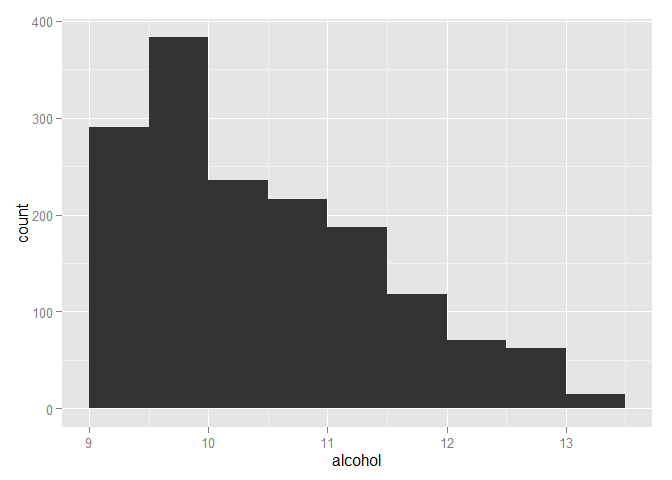

## Graph of count vs. quality

## What is the mean quality of wines?

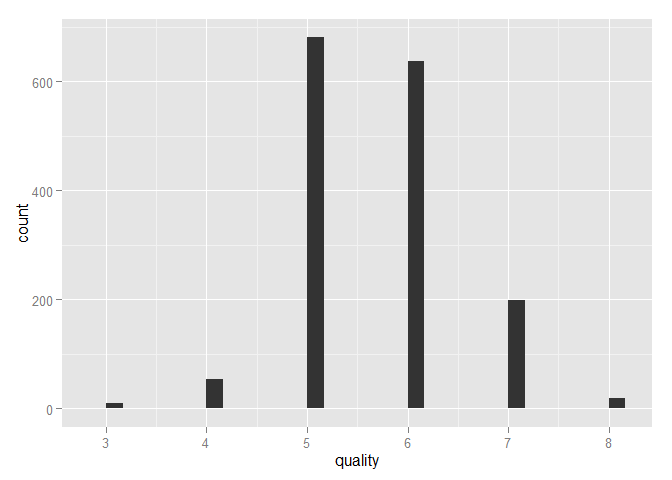

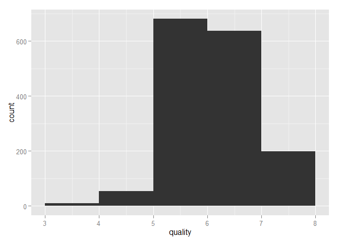

```
##    Min. 1st Qu.  Median    Mean 3rd Qu.    Max.
##   3.000   5.000   6.000   5.636   6.000   8.000
```

#### Although the quality of wines can vary from 0 to 10, most values of quality

#### of wines in the dataset lie in the range 5-8. The minimum is 3 and the maximum

#### is 8. Fortunately, we don’t have any values below 0 or above 10. The most common

#### value for quality is 5.

#### There are several variables given as a part of the data set. However, there are

#### not many easy to percieve variables. I am going to make two variables called

#### taste and acidity to makes things easier to interpret.

## Graph of count vs. taste

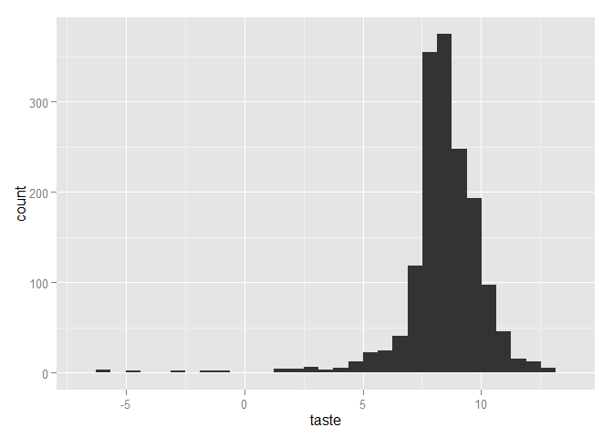

```
##    Min. 1st Qu.  Median    Mean 3rd Qu.    Max.
##  -6.020   7.780   8.445   8.412   9.280  12.780
```

```
##    Mode   FALSE    TRUE    NA's
## logical    1576      23       0
```

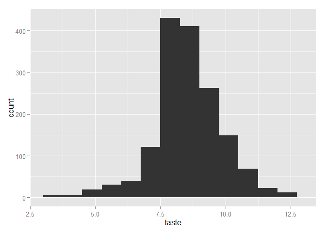

#### New variable that I added to the dataset:

#### Taste is major contributor to the quality. I have chosen to define taste

#### as taste = volatile acid - residual sugar+ alcohol. The reason I chose these

#### variables is because (according to the information of the dataset document)

#### the volatile acid and alcohol are the main contributors of sour taste and

#### residual sugar is the main contributor of sweet taste. Additionally, the amount

#### of alcohol influences the taste.The taste values’ minimum is at -6.020 and the

#### maximum at 12.78. Most wines have a taste value between 7.78 and 9.28. There

#### are a few outliers because there are only 6 occurences of wine wherein the

#### taste is less than -3.

## Graph of count vs. acidity

### How acidic are wines (average)?

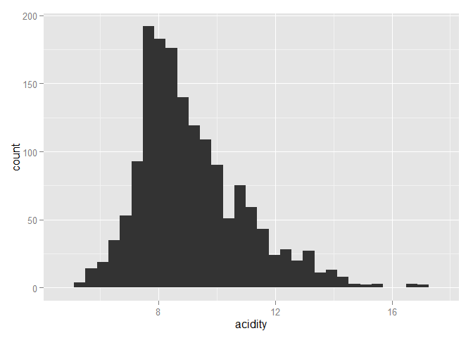

```
##    Min. 1st Qu.  Median    Mean 3rd Qu.    Max.
##   5.270   7.827   8.720   9.118  10.070  17.050
```

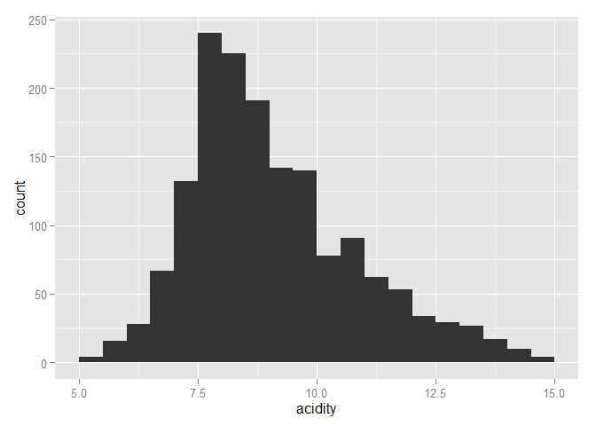

#### 5.27 (minimum) and 17.05(maximum). Most values are between 7.82 and 10.07.

# Univariate Analysis

### What is the structure of your dataset?

#### There are 1599 objects in this data set; it has 12 different variables. The

#### types of all the variables are int and num. The variables are : fixed.acidity,

#### volatile.acidity, citric.acid, residual.sugar, chlorides, free.sulfur.dioxide,

#### total.sulfur.dioxide, density, pH, sulfates, alcohol and quality. x is like a

#### serial number. Quality is an integer value between 0 and 10.

### Other observations:

#### the maximum possible value is 10).

### What is/are the main feature(s) of interest in your dataset?

#### I think the main features are pH, alcohol and quality. I would like to

#### determine which features (of the given variables) best predict the quality

#### of red wines. I think that pH, alcohol, acidity, density and other factors

#### influence the quality of red wine and that a combination of these variables

#### (and some other variables) can be used to create a predictive model.

### What other features in the dataset do you think will help support your

### investigation into your feature(s) of interest?

#### Alcohol content, citric acid, volatile acid, pH and residual sugar are

#### likely to contribute to the quality of red wines. Since acetic acid and

#### residual sugar control sourness and sweetness of the wine, these are

#### likely to contribute to quality significantly.

### Did you create any new variables from existing variables in the dataset?

#### I created a new variable called taste that calculates the taste of a wine by

#### using the volatile acid, alcohol content and residual sugar values.

#### I created a new variable called acidity that represents the total acidity of

#### the wine by summing the values of - tartaric acid, acetic acid and citric acid.

### Of the features you investigated, were there any unusual distributions?

### Did you perform any operations on the data to tidy, adjust, or change the form

### of the data? If so, why did you do this?

#### [More details are there near the associated graphs.]

#### Next, I would like to explore the bivariate relationships that exist.

# Bivariate Plots Section

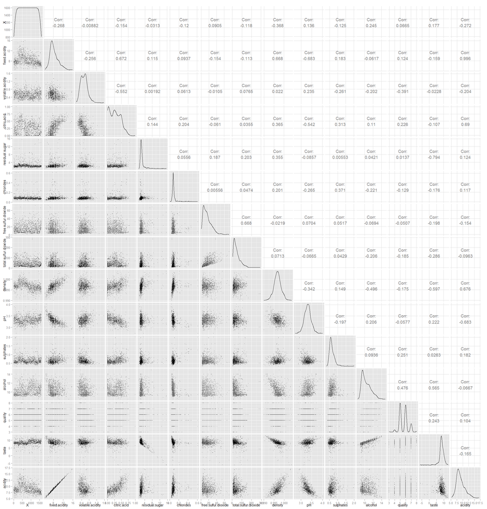

#### There seems to be high correlation between alcohol content and quality.

#### In the following plots, I will be investigating the relations between

#### alcohol, desity,pH,etc. and the quality.

#### Acidity and ph, and acidity and density have very high correlation values

#### Hence, I will be exploring these relationahips in more detail.

#### Additionally, I seek to discover other bivariate relationships in this

#### section

### How do the various acidity values contribute to quality?

### What are the correlation values?

## Graph of fixed.acidity vs.quality

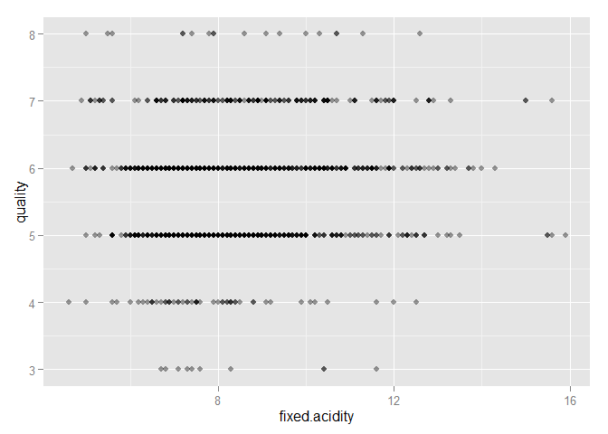

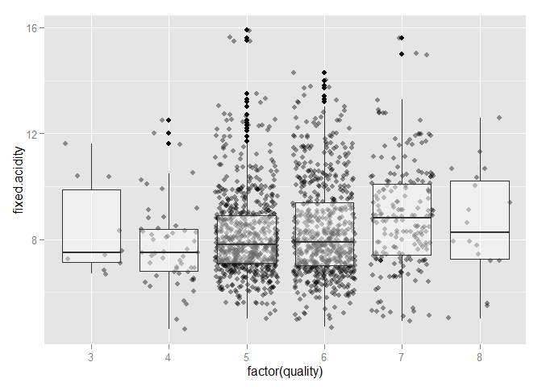

```
##
##  Pearson's product-moment correlation
##
## data:  pf$quality and pf$fixed.acidity
## t = 4.996, df = 1597, p-value = 6.496e-07
## alternative hypothesis: true correlation is not equal to 0
## 95 percent confidence interval:
##  0.07548957 0.17202667
## sample estimates:
##       cor
## 0.1240516
```

#### Correlation value of 0.124 indicates that fixed acidity value does not

#### strongly influence the quality linearly.

#### However, it can be noted that alcohol with quality=7 has the best average

#### fixed.acidity.

## Graph of volatile.acidity vs.quality

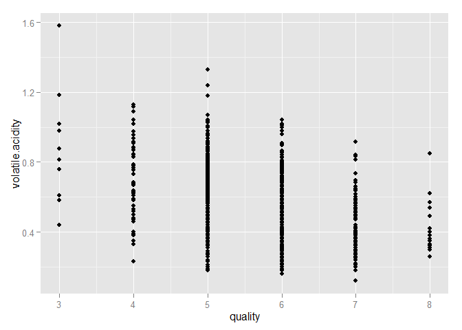

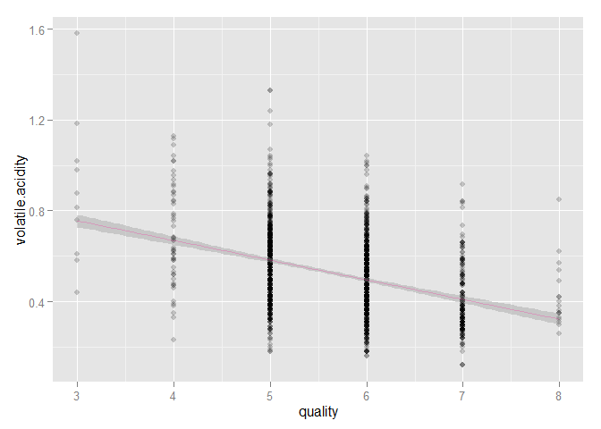

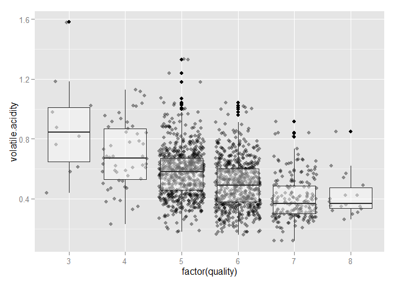

```
##
##  Pearson's product-moment correlation
##
## data:  pf$quality and pf$volatile.acidity
## t = -16.954, df = 1597, p-value < 2.2e-16
## alternative hypothesis: true correlation is not equal to 0
## 95 percent confidence interval:
##  -0.4313210 -0.3482032
## sample estimates:
##        cor
## -0.3905578
```

#### Correlation value of-0.39 indicates that volatile acidity value does not

#### strongly influence the quality linearly. But, definitely a negative linear

#### relationship does exist.

#### From the boxplot, it can be noted that lower the volatile acidity,higher

#### the quality [inversely proportional].

## Graph of residual sugar vs.quality

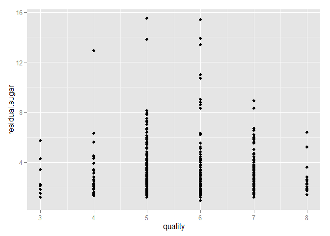

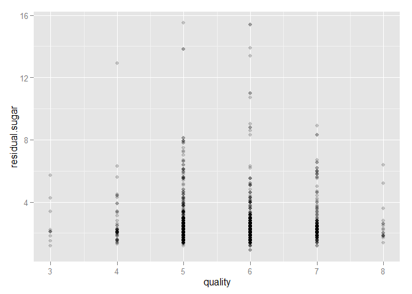

```
##
##  Pearson's product-moment correlation
##
## data:  pf$quality and pf$residual.sugar
## t = 0.5488, df = 1597, p-value = 0.5832
## alternative hypothesis: true correlation is not equal to 0
## 95 percent confidence interval:
##  -0.03531327  0.06271056
## sample estimates:
##        cor
## 0.01373164
```

#### Correlation value is extremely low (as expected by looking the graph) -

#### 0.013. Residual sugar is not a good predictor of quality.

## Graph of chlorides vs.quality

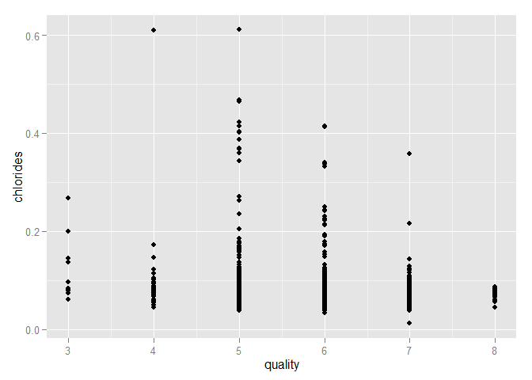

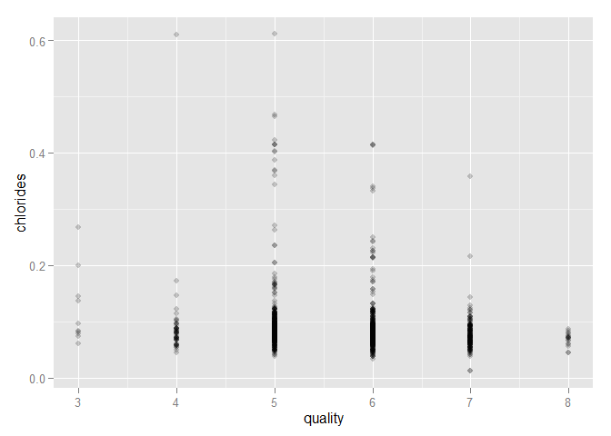

```
##
##  Pearson's product-moment correlation
##
## data:  pf$quality and pf$chlorides
## t = -5.1948, df = 1597, p-value = 2.313e-07
## alternative hypothesis: true correlation is not equal to 0
## 95 percent confidence interval:
##  -0.17681041 -0.08039344
## sample estimates:
##        cor
## -0.1289066
```

#### Correlation value is -0.13 and chlorides is not a major influence of

#### quality.

## Graph of citric.acid vs.quality

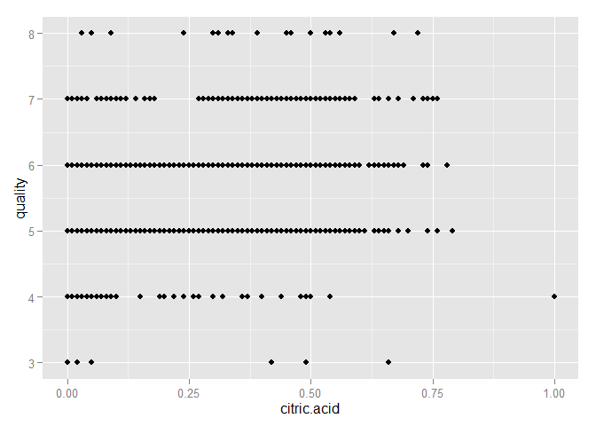

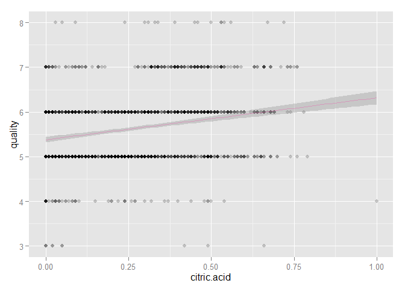

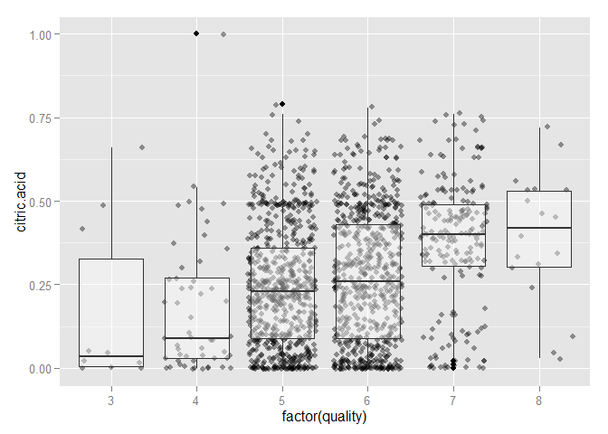

```
##
##  Pearson's product-moment correlation
##
## data:  pf$quality and pf$citric.acid
## t = 9.2875, df = 1597, p-value < 2.2e-16
## alternative hypothesis: true correlation is not equal to 0
## 95 percent confidence interval:
##  0.1793415 0.2723711
## sample estimates:
##       cor
## 0.2263725
```

#### Graph does not imply a relationship probably because quality depends on

#### several variables. The correlation value is low- 0.22.

#### Hence, these is weak linear relationship between citric acid and quality.

#### From the boxplot it can be noted that as the citric acid level increases,

#### the quality increases.

## Graph of taste vs.quality

### Does the new variable - taste predict quality?

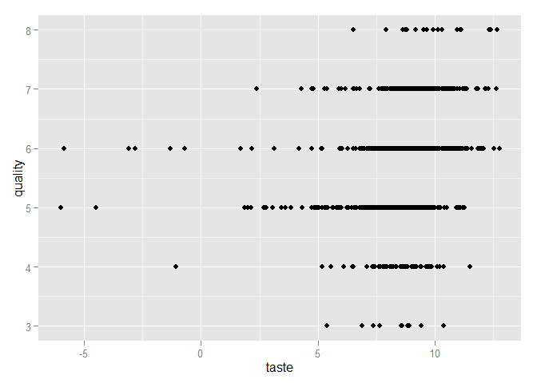

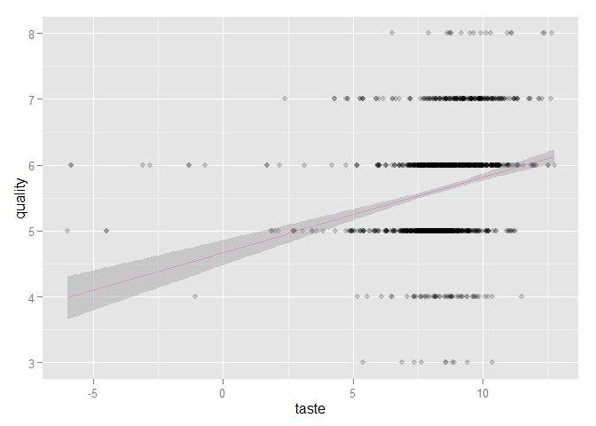

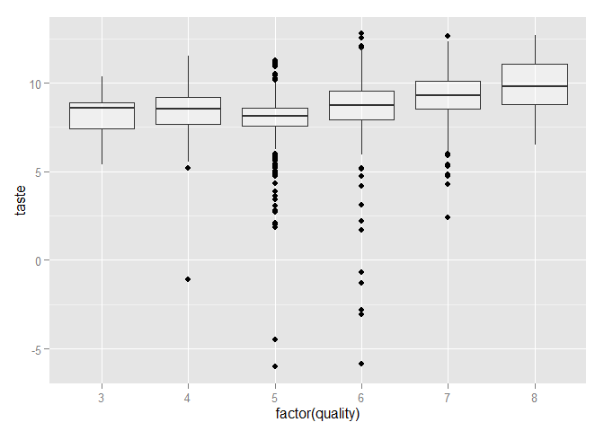

```
##
##  Pearson's product-moment correlation
##
## data:  pf$quality and pf$taste
## t = 10.029, df = 1597, p-value < 2.2e-16
## alternative hypothesis: true correlation is not equal to 0
## 95 percent confidence interval:
##  0.1967363 0.2889829
## sample estimates:
##     cor
## 0.24341
```

#### Graph does not imply a relationship probably because quality depends on

#### several variables. The correlation value is low (but relatively high)- 0.243.

#### Hence, the new variable I have created is a decent indicator of quality.

#### Also, as the taste increases, the quality increases [from the boxplot].

## Graph of acidity vs.quality

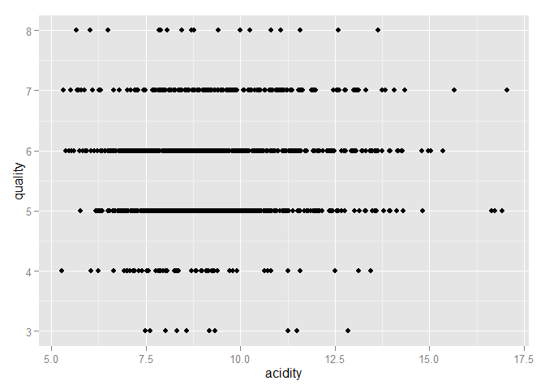

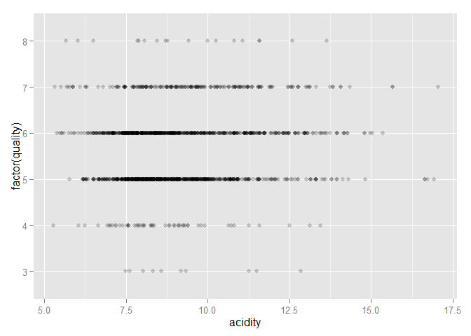

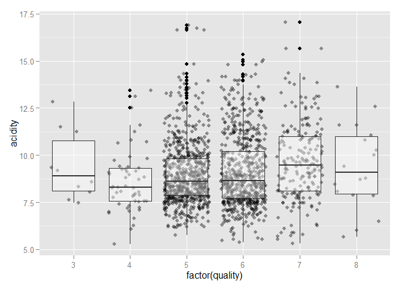

```
##
##  Pearson's product-moment correlation
##
## data:  pf$quality and pf$acidity
## t = 4.1688, df = 1597, p-value = 3.227e-05
## alternative hypothesis: true correlation is not equal to 0
## 95 percent confidence interval:
##  0.05501239 0.15200177
## sample estimates:
##       cor
## 0.1037537
```

#### Graph does not imply a relationship probably because quality depends on

#### several variables. The correlation value is low- 0.10. Hence, the new variable

#### I have created is not a good indicator of quality.

## Graphs of sulfur dioxide (total and free) vs.quality

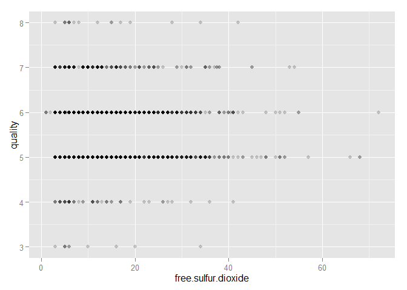

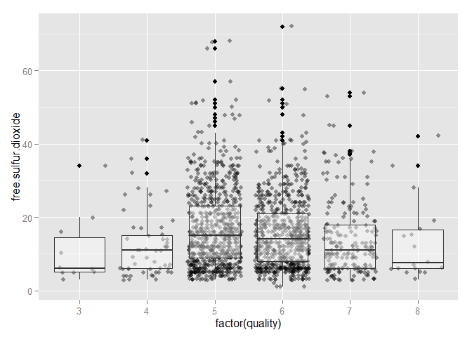

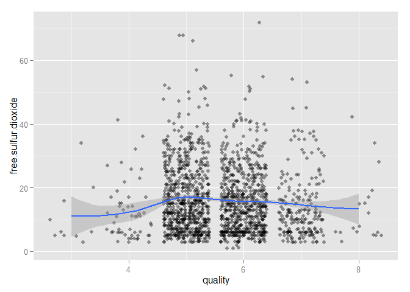

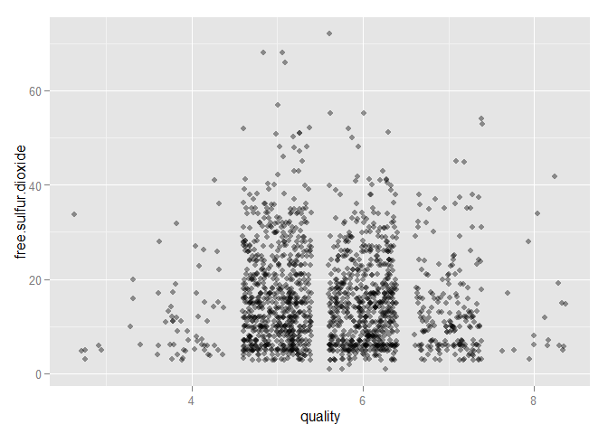

```
##
##  Pearson's product-moment correlation
##
## data:  pf$quality and pf$free.sulfur.dioxide
## t = -2.0269, df = 1597, p-value = 0.04283
## alternative hypothesis: true correlation is not equal to 0
## 95 percent confidence interval:
##  -0.099430290 -0.001638987
## sample estimates:
##         cor
## -0.05065606
```

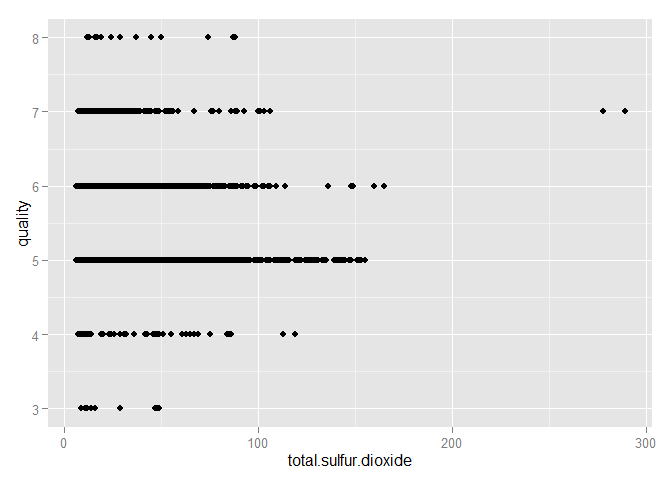

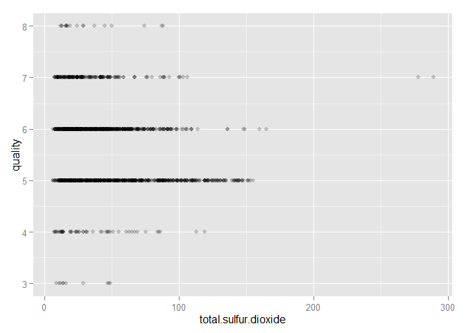

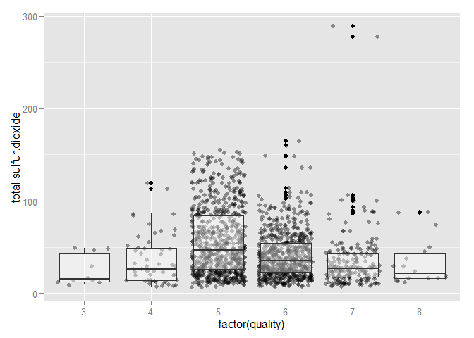

```
##
##  Pearson's product-moment correlation
##
## data:  pf$quality and pf$total.sulfur.dioxide
## t = -7.5271, df = 1597, p-value = 8.622e-14
## alternative hypothesis: true correlation is not equal to 0
## 95 percent confidence interval:
##  -0.2320162 -0.1373252
## sample estimates:
##        cor
## -0.1851003
```